# CPLN 675 Midterm Project: Flood Inundation.

## 5.5 Map Prediction

```r
allPredictions2 <-
  predict(Inundation_cvFit2, Calgary_dat_new2, type="prob")[,2]

Calgary_dat_new2 <-
  cbind(Calgary_dat_new2,allPredictions2) %>%
  mutate(allPredictions2 = round(allPredictions2 * 100))
```

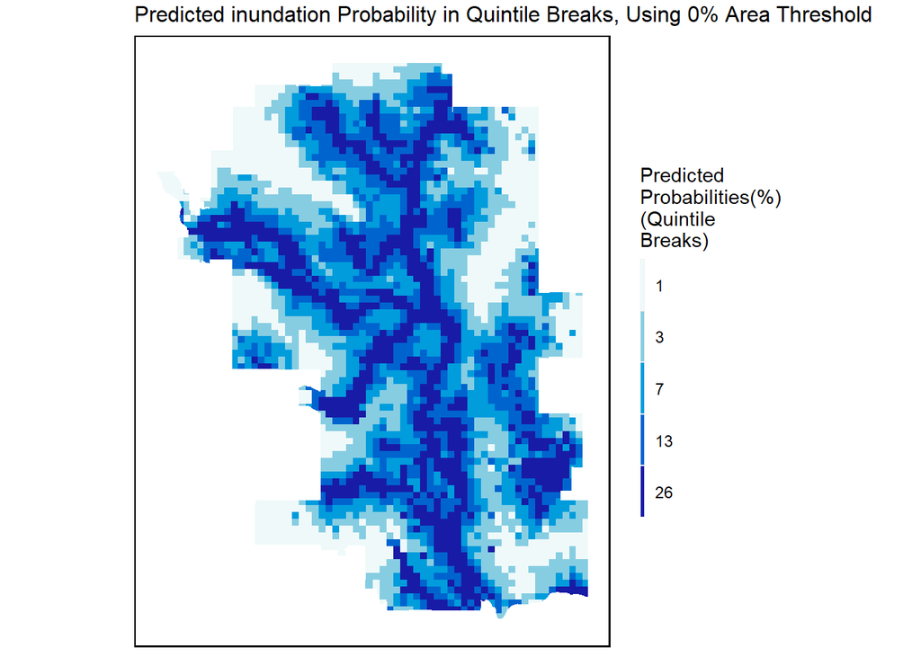

```r
ggplot() +
    geom_sf(data=Calgary_dat_new2, aes(fill=factor(ntile(allPredictions2,5))),
            colour=NA) +
    scale_fill_manual(values = c("#eff9f9","#86cde2","#009cdc","#0064cf","#181ba6"),
                      labels=as.character(quantile(Calgary_dat_new2$allPredictions2,
                                                 c(0.1,.2,.4,.6,.8),
                                                 na.rm=T)),
                      name="Predicted\nProbabilities(%)\n(Quintile\nBreaks)") +
  mapTheme +
  labs(title="Predicted inundation Probability in Quintile Breaks, Using 0% Area Threshold")
```

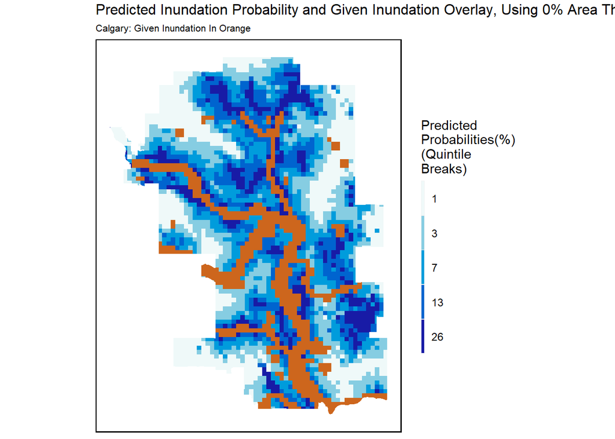

```r
ggplot() +
    geom_sf(data=Calgary_dat_new2, aes(fill=factor(ntile(allPredictions2,5))),
            colour=NA) +
    scale_fill_manual(values = c("#eff9f9","#86cde2","#009cdc","#0064cf","#181ba6"),
                      labels=as.character(quantile(Calgary_dat_new2$allPredictions2,
                                                 c(0.1,.2,.4,.6,.8),
                                                 na.rm=T)),
                      name="Predicted\nProbabilities(%)\n(Quintile\nBreaks)") +
  geom_sf(data=Calgary_dat_new2 %>%
               filter(Inundation_indicator == 1),
               fill="chocolate3",colour=NA) +
  mapTheme +
 labs(title="Predicted Inundation Probability and Given Inundation Overlay, Using 0% Area Threshold",
      subtitle="Calgary: Given Inundation In Orange")
```

## 5.6 Map Confusion Matrix

As the confusion matrix map shows, compared to the model in step 3, this model successfully predicted more true-positive cells, but also generated more false-positive results. Such over predict of false-positive may lead to over-expenditure if planning based on this model.

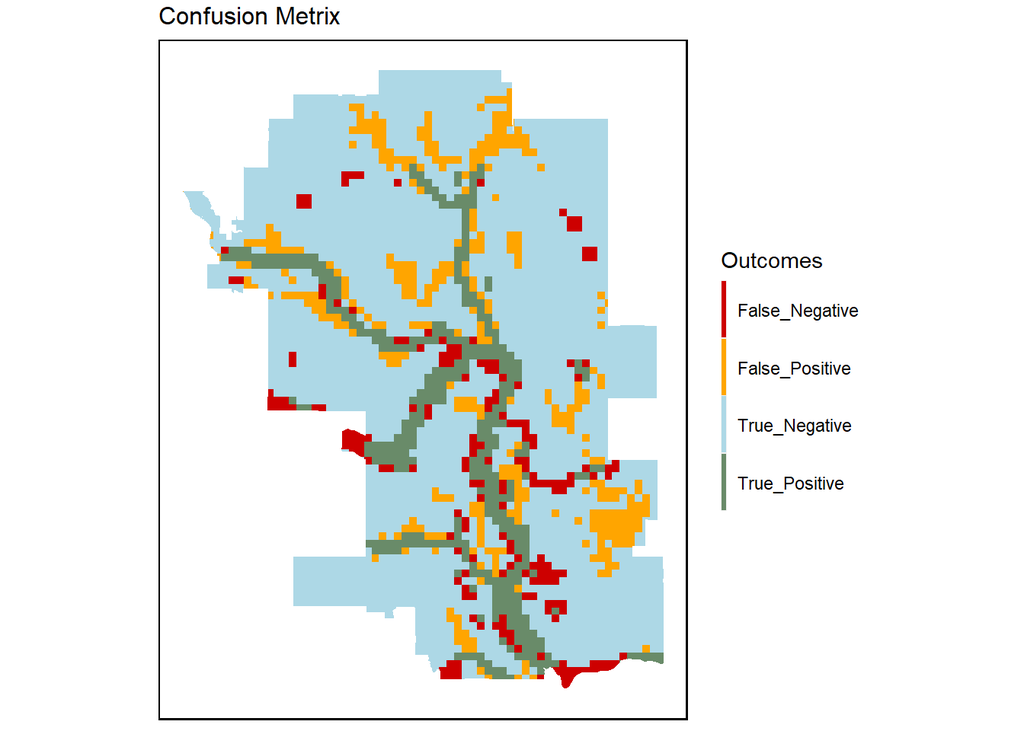

```r
Calgary_dat_new2 %>%
  mutate(cmResult=case_when(allPredictions2 < 25 & Inundation_indicator==0 ~ "True_Negative",
                              allPredictions2 >= 25 & Inundation_indicator==1 ~ "True_Positive",
                              allPredictions2 < 25 & Inundation_indicator==1 ~ "False_Negative",
                              allPredictions2 >= 25 & Inundation_indicator==0 ~ "False_Positive")) %>%
  ggplot()+
  geom_sf(aes(fill = cmResult), color = "transparent")+
  scale_fill_manual(values = c("red3","Orange","Light Blue","darkseagreen4"),
                    name="Outcomes")+
  labs(title="Confusion Metrix") +
  mapTheme
```

## 5.7 Predicted Inundation Area

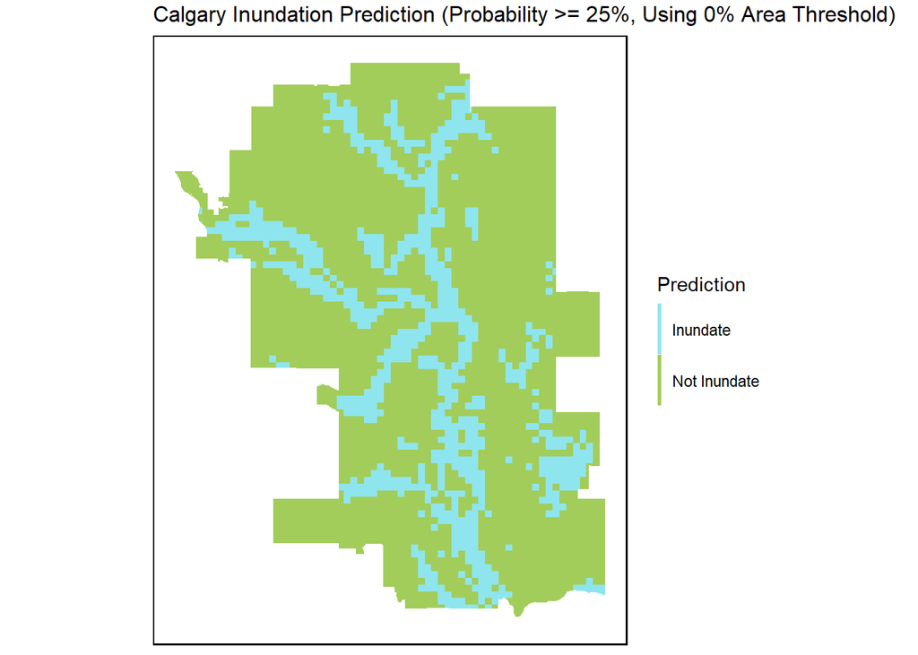

```r
Calgary_dat_new2 <-
  Calgary_dat_new2 %>%
  mutate(Will_Inundate = ifelse(allPredictions2 < 25,1,0))

ggplot() +
    geom_sf(data=Calgary_dat_new2, aes(fill=factor(Will_Inundate)), colour=NA) +
    scale_fill_manual(values = c("cadetblue2","darkolivegreen3"),
                      labels=c("Inundate","Not Inundate"),
                      name="Prediction") +
  mapTheme+
  labs(title="Calgary Inundation Prediction (Probability >= 25%, Using 0% Area Threshold)")
```

## 5.8 Apply on Edmonton

```r
Edmonton_Inundation_classProbs2 <- predict(InundationModel4, Edmonton_dat_new, type="response")

Edmonton_dat_new <-
  cbind(Edmonton_dat_new,Edmonton_Inundation_classProbs2) %>%
  mutate(Edmonton_Inundation_classProbs2 = round(Edmonton_Inundation_classProbs2 * 100))
```

## 5.9 Visualize on Edmonton

As the result below shows, if we apply a 0% area threshold to the dataset and adjusted the model, the prediction will overly estimate the flood area. Therefore, it might be improper to consider a cell as inundated when any percentage of it is deemed as inundation from the aerial image, and the result from the 25% area threshold seems to be more applicable in this case.

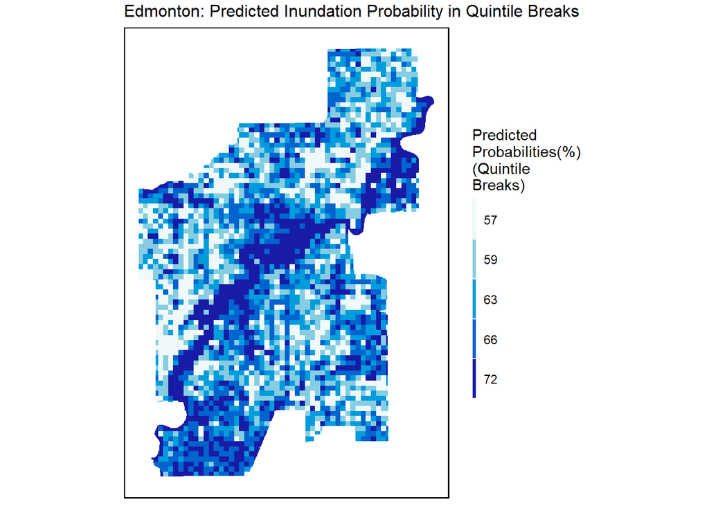

```r
ggplot() +
    geom_sf(data=Edmonton_dat_new, aes(fill=factor(ntile(Edmonton_Inundation_classProbs2,5))),
            colour=NA) +
    scale_fill_manual(values = c("#eff9f9","#86cde2","#009cdc","#0064cf","#181ba6"),
                      labels=as.character(quantile(Edmonton_dat_new$Edmonton_Inundation_classProbs2,
                                                 c(0.1,.2,.4,.6,.8),
                                                 na.rm=T)),
                      name="Predicted\nProbabilities(%)\n(Quintile\nBreaks)") +
  mapTheme +
  labs(title="Edmonton: Predicted Inundation Probability in Quintile Breaks")
```

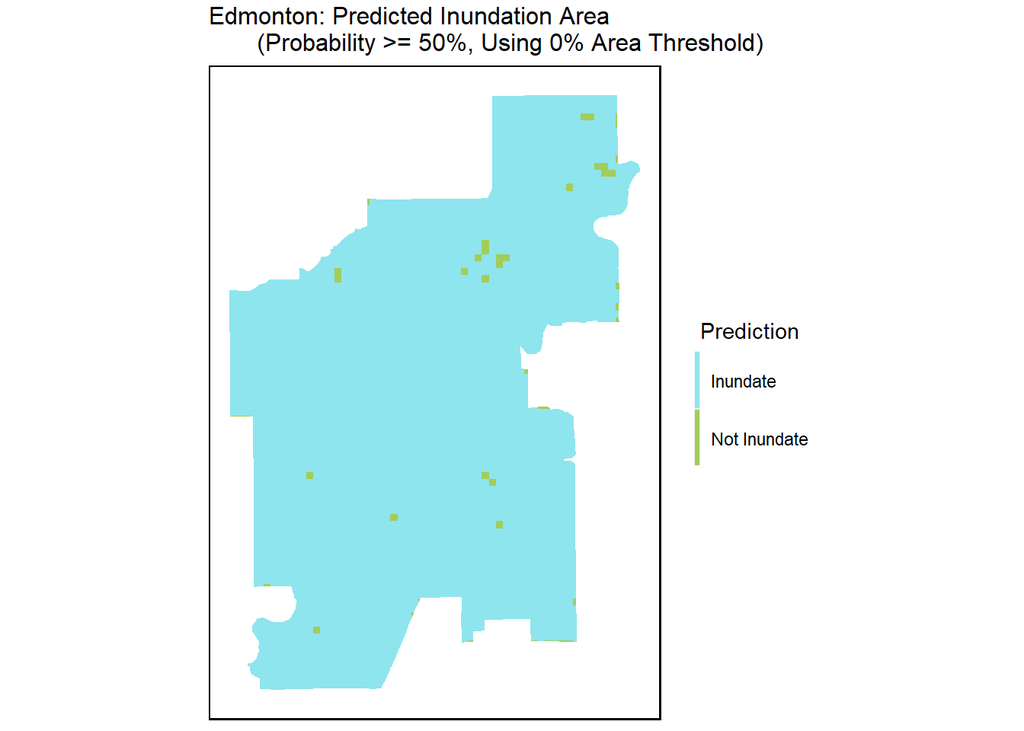

```r
# Based on our assumption, a cell will be considered as Inundated when the probability of Inundation exceed 25%.
Edmonton_dat_new <-
  Edmonton_dat_new %>%
  mutate(Will_Inundate2 = ifelse(Edmonton_Inundation_classProbs2 < 50,1,0))

ggplot() +
    geom_sf(data=Edmonton_dat_new, aes(fill=factor(Will_Inundate2)), colour=NA) +
    scale_fill_manual(values = c("cadetblue2","darkolivegreen3"),
                      labels=c("Inundate","Not Inundate"),
                      name=" Prediction") +
  mapTheme +
  labs(title="Edmonton: Predicted Inundation Area
       (Probability >= 50%, Using 0% Area Threshold)")
```

# Link to Video

Option 1: https://youtu.be/PwNjDhAYWUQ Option 2: https://upenn.zoom.us/rec/share/ByedasPQH0hwPY63pajg7NbDt68OZCFplU6LOu2-epp_nWGXHD3JcrdUNqZW9uB7.csKNj0oceOLdP6Xj?startTime=1648610924000 (Passcode: 7?2hRvq4)